# Homework 02

## Question 1: Training and test error under a fixed design

Consider a linear regression problem with $n=100$ observations and $p=20$ available covariates. Generate one matrix $\mathbf X_{\mathrm{all}}\in\mathbb R^{n\times p}$ whose entries are independent $\mathcal N(0,1)$ random variables, and then keep this realized matrix fixed. Let

$$\beta_j=0.4^{\sqrt{j}},
\qquad j=1,\ldots,p,$$

and define

$$\boldsymbol\mu=\mathbf X_{\mathrm{all}}\boldsymbol\beta.$$

Generate one training response and one independent test response from

$$\begin{aligned}
\mathbf y
&=\boldsymbol\mu+\boldsymbol\epsilon,\\
\mathbf y^*
&=\boldsymbol\mu+\boldsymbol\epsilon^*,
\end{aligned}$$

where

$$\boldsymbol\epsilon,\boldsymbol\epsilon^*
\overset{\mathrm{ind}}{\sim}
\mathcal N_n(\mathbf 0,\mathbf I_n).$$

Here $\mathbf I_n$ is the $n\times n$ identity matrix.

For $m=0,1,\ldots,p$, fit a linear model with an intercept and the first $m$ columns of $\mathbf X_{\mathrm{all}}$ using $\mathbf y$. If $\widehat{\mathbf y}_m$ is its fitted mean vector, define

$$\operatorname{MSE}_{\mathrm{train},m}
=\frac{1}{n}
\left\lVert
\mathbf y-\widehat{\mathbf y}_m
\right\rVert_2^2,$$

and

$$\operatorname{MSE}_{\mathrm{test},m}
=\frac{1}{n}
\left\lVert
\mathbf y^*-\widehat{\mathbf y}_m
\right\rVert_2^2.$$

Repeat this process independently 200 times, keeping $\mathbf X_{\mathrm{all}}$ fixed.

Use seed `43202` before generating $\mathbf X_{\mathrm{all}}$ and the response errors. R and Python use different random-number generators, so their exact numerical values need not agree.

1. For each $m$, calculate the average training and test MSE over the 200 simulation runs. Plot both curves against $m$. Verify numerically that training MSE does not increase as predictors are added in each simulation run.
2. For the model containing the first $m$ predictors, write

$$\mathbf X_m
=
[\mathbf 1,\mathbf x_1,\ldots,\mathbf x_m],
\qquad
\mathbf H_m
=
\mathbf X_m
(\mathbf X_m^{\mathsf T}\mathbf X_m)^{-1}
\mathbf X_m^{\mathsf T}.$$

Here $\mathbf X_m\in\mathbb R^{n\times(m+1)}$ and $\mathbf H_m\in\mathbb R^{n\times n}$. The model has $m+1$ fitted coefficients, including the intercept. Define its **total squared approximation bias** as

$$B_m^2
=\left\lVert
(\mathbf I_n-\mathbf H_m)\boldsymbol\mu
\right\rVert_2^2.$$

Thus, $B_m^2/n$ is the mean squared approximation bias.

Calculate the two theoretical expectations

$$E\!\left(
\operatorname{MSE}_{\mathrm{train},m}
\mid \mathbf X_{\mathrm{all}}
\right)
=\frac{B_m^2}{n}+1-\frac{m+1}{n},$$

and

$$E\!\left(
\operatorname{MSE}_{\mathrm{test},m}
\mid \mathbf X_{\mathrm{all}}
\right)
=\frac{B_m^2}{n}+1+\frac{m+1}{n}.$$

Add these expectations to your plot and compare them with the simulation averages.

3. Add the test MSE curve from one simulation run to the plot. Explain why this single curve is less smooth than the average test MSE. Use the approximation-bias and estimation-variance terms in the expected test MSE to explain why training MSE cannot be used by itself to select the predictor count.

### Solution

**Show the starter code**

```r
set.seed(43202)
n <- 100
p <- 20
n_rep <- 200

X_all <- matrix(rnorm(n * p), nrow = n, ncol = p)
beta <- 0.4^sqrt(1:p)
mu <- as.numeric(X_all %*% beta)

mse_for_m <- function(y_train, y_test, m) {
  Xm <- cbind(1, X_all[, seq_len(m), drop = FALSE])
  coef_m <- lm.fit(Xm, y_train)$coefficients
  y_hat <- as.numeric(Xm %*% coef_m)
  c(train = mean((y_train - y_hat)^2), test = mean((y_test - y_hat)^2))
}

train_mat <- matrix(NA_real_, n_rep, p + 1)
test_mat <- matrix(NA_real_, n_rep, p + 1)

for (r in seq_len(n_rep)) {
  y_train <- mu + rnorm(n)
  y_test <- mu + rnorm(n)
  both <- sapply(0:p, mse_for_m, y_train = y_train, y_test = y_test)
  train_mat[r, ] <- both["train", ]
  test_mat[r, ] <- both["test", ]
}

avg_train <- colMeans(train_mat)
avg_test <- colMeans(test_mat)

train_is_nonincreasing <- all(
  apply(train_mat, 1, function(row) all(diff(row) <= 1e-9))
)
cat("Training MSE is non-increasing in m, in all 200 runs:",
    train_is_nonincreasing, "\n")
```

```
Training MSE is non-increasing in m, in all 200 runs: TRUE
```

Training MSE never increases as $m$ grows in any of the 200 runs, because each modelcontains the previous model, so the residual sum of squares cannot go up when a column is added.

**Show the starter code**

```r
hat_bias_mse <- function(m) {
  Xm <- cbind(1, X_all[, seq_len(m), drop = FALSE])
  Hm <- Xm %*% solve(crossprod(Xm), t(Xm))
  resid_mu <- (diag(n) - Hm) %*% mu
  mean(resid_mu^2)
}

bias_mse <- sapply(0:p, hat_bias_mse)
theory_train <- bias_mse + 1 - (0:p + 1) / n
theory_test <- bias_mse + 1 + (0:p + 1) / n

summary_tbl <- data.frame(
  m = 0:p,
  avg_train = avg_train, theory_train = theory_train,
  avg_test = avg_test, theory_test = theory_test
)
print(round(summary_tbl[c(1, 6, 11, 16, 21), ], 4), row.names = FALSE)
```

```
  m avg_train theory_train avg_test theory_test
  0    1.3147       1.2974   1.3367      1.3174
  5    0.9806       0.9750   1.0979      1.0950
 10    0.9061       0.8992   1.1186      1.1192
 15    0.8524       0.8419   1.1594      1.1619
 20    0.7948       0.7900   1.2170      1.2100
```

**Show the starter code**

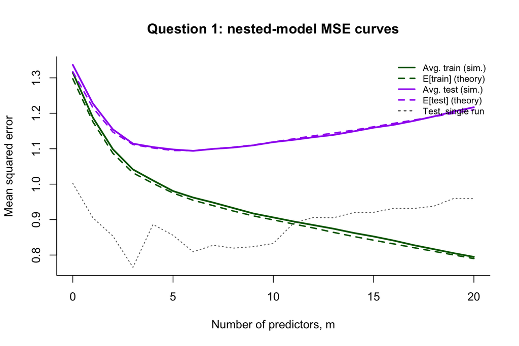

```r
plot(
  0:p, avg_train, type = "l", lwd = 2.4, col = "darkgreen",
  ylim = range(c(avg_train, theory_train, avg_test, theory_test, test_mat[1, ])),
  xlab = "Number of predictors, m", ylab = "Mean squared error",
  bty = "l", main = "Question 1: nested-model MSE curves"
)
lines(0:p, theory_train, lty = 2, lwd = 2, col = "darkgreen")
lines(0:p, avg_test, lwd = 2.4, col = "purple")
lines(0:p, theory_test, lty = 2, lwd = 2, col = "purple")
lines(0:p, test_mat[1, ], lty = 3, lwd = 1.3, col = "gray45")
legend(
  "topright", bty = "n", cex = 0.78,
  legend = c("Avg. train (sim.)", "E[train] (theory)",
             "Avg. test (sim.)", "E[test] (theory)", "Test, single run"),
  col = c("darkgreen", "darkgreen", "purple", "purple", "gray45"),
  lty = c(1, 2, 1, 2, 3), lwd = 2
)
```

**Show the starter code**

```r
cat("Minimizer of average simulated test MSE: m =", which.min(avg_test) - 1, "\n")
```

```
Minimizer of average simulated test MSE: m = 6
```

**Show the starter code**

```r
cat("Minimizer of expected test MSE:          m =", which.min(theory_test) - 1, "\n")
```

```
Minimizer of expected test MSE:          m = 6
```

3. The gray dotted curve is less smooth because it reflects the sampling noise from one particular $\boldsymbol{\epsilon}$ and $\boldsymbol{\epsilon}^*$, while the purple curve averages over 200 runs and therefore smooths out this random variation.

Expected test MSE reflects a trade-off between approximation bias, which decreases as more predictors are added, and estimation variance, which increases with the number of predictors. In contrast, training MSE always decreases as predictors are added because its variance term has the opposite sign. Thus, training MSE alone cannot identify the predictor count that minimizes test MSE.

## Question 2: Prediction error at one target point

Let $n=100$, $p=6$, and $\sigma^2=1$. Construct the fixed covariate matrix $\mathbf X_{\mathrm{all}}\in\mathbb R^{n\times p}$ with entries

$$(\mathbf X_{\mathrm{all}})_{ij}
=\sqrt{2}\cos\left\{
\frac{\pi j(i-\tfrac12)}{n}
\right\},
\qquad
i=1,\ldots,n,
\quad
j=1,\ldots,p.$$

Its columns satisfy

$$\mathbf 1^{\mathsf T}\mathbf X_{\mathrm{all}}=\mathbf 0^{\mathsf T},
\qquad
\frac{1}{n}\mathbf X_{\mathrm{all}}^{\mathsf T}\mathbf X_{\mathrm{all}}=\mathbf I_p.$$

Here $\mathbf I_p$ is the $p\times p$ identity matrix.

The following code shows a direct construction of $\mathbf X_{\mathrm{all}}$.

**R**

**Show the starter code**

```r
n <- 100
p <- 6
X_all <- outer(
  1:n, 1:p,
  function(i, j) sqrt(2) * cos(pi * j * (i - 0.5) / n)
)
```

Keep $\mathbf X_{\mathrm{all}}$ fixed and generate one training response from

$$\mathbf y
=\mathbf X_{\mathrm{all}}\boldsymbol\beta+\boldsymbol\epsilon,
\qquad
\boldsymbol\beta
=(0.5,0.5,0.5,0.5,0.5,0.5)^{\mathsf T},$$

where

$$\boldsymbol\epsilon
\sim
\mathcal N_n(\mathbf 0,\mathbf I_n).$$

Here $\mathbf I_n$ is the $n\times n$ identity matrix.

For $m=0,\ldots,p$, fit a linear model with an intercept and the first $m$ predictors. Consider prediction of the mean response at

$$\mathbf x_0=(0,1,0,0,1,0)^{\mathsf T}.$$

Write

$$\mu_0=\mathbf x_0^{\mathsf T}\boldsymbol\beta,$$

and let $\widehat\mu_{0,m}$ be the prediction from the model containing the first $m$ predictors. Here $x_{0j}$ denotes the $j$th coordinate of $\mathbf x_0$. For this design,

$$E\!\left[
\left(\widehat\mu_{0,m}-\mu_0\right)^2
\mid \mathbf X_{\mathrm{all}}
\right]
=
\left(
\sum_{j=m+1}^{p}x_{0j}\beta_j
\right)^2
+\frac{\sigma^2}{n}
\left(
1+\sum_{j=1}^{m}x_{0j}^2
\right).$$

1. Calculate $\mu_0$, the theoretical squared bias, and the expected squared error for $m=0,\ldots,p$ using the formula above. **You do not need to derive the formula.** Briefly explain in words why it consists of a squared bias term from omitted predictors and a variance term from estimating coefficients; no proof is required. Identify the values of $m$ where the expected squared error changes and where it remains unchanged.
2. Use seed `43203`. Generate the response, fit the models, and calculate

$$\left(\widehat\mu_{0,m}-\mu_0\right)^2.$$

Repeat this independently 200 times. Plot the simulation averages and theoretical expectations together. Report the smallest $m$ that minimizes the theoretical error.

3. All six regression coefficients are nonzero. Explain why only predictors 2 and 5 contribute directly to the mean response at $\mathbf x_0$. Contrast this target-specific error with the test MSE averaged over all rows of $\mathbf X_{\mathrm{all}}$ in Question 1.

## Solution

**Show the starter code**

```r
n2 <- 100
p2 <- 6
sigma2 <- 1
beta2 <- rep(0.5, p2)
x0 <- c(0, 1, 0, 0, 1, 0)
mu0 <- sum(x0 * beta2)
cat("mu0 =", mu0, "\n")
```

```
mu0 = 1
```

**Show the starter code**

```r
theory_row <- function(m) {
  omitted_idx <- if (m < p2) (m + 1):p2 else integer(0)
  sq_bias <- (sum(x0[omitted_idx] * beta2[omitted_idx]))^2
  variance <- sigma2 * (1 + sum(x0[seq_len(m)]^2)) / n2
  c(m = m, squared_bias = sq_bias, variance = variance,
    expected_error = sq_bias + variance)
}

theory_tbl <- t(sapply(0:p2, theory_row))
print(round(theory_tbl, 4))
```

```
     m squared_bias variance expected_error
[1,] 0         1.00     0.01           1.01
[2,] 1         1.00     0.01           1.01
[3,] 2         0.25     0.02           0.27
[4,] 3         0.25     0.02           0.27
[5,] 4         0.25     0.02           0.27
[6,] 5         0.00     0.03           0.03
[7,] 6         0.00     0.03           0.03
```

Only predictors 2 and 5 are nonzero in $\mathbf{x}_0$, so the expected error is flat for $m=0!-!1$, decreases when predictor 2 enters ($m=2!-!4$), and reaches the variance floor when predictor 5 enters ($m=5,6$). The squared bias comes from signal in omitted predictors, while the variance comes from estimating the coefficients of included predictors. Because the design columns are orthogonal, the coefficient estimates are uncorrelated and their variances add.

**b. Simulation with seed `43203`.**

**Show the starter code**

```r
set.seed(43203)
X_all2 <- outer(1:n2, 1:p2, function(i, j) sqrt(2) * cos(pi * j * (i - 0.5) / n2))
mu2 <- as.numeric(X_all2 %*% beta2)
n_rep2 <- 200

sq_err <- matrix(NA_real_, n_rep2, p2 + 1)
for (r in seq_len(n_rep2)) {
  y <- mu2 + rnorm(n2)
  for (m in 0:p2) {
    Xm <- cbind(1, X_all2[, seq_len(m), drop = FALSE])
    beta_hat <- solve(crossprod(Xm), crossprod(Xm, y))
    x0_row <- c(1, x0[seq_len(m)])
    mu0_hat <- sum(x0_row * beta_hat)
    sq_err[r, m + 1] <- (mu0_hat - mu0)^2
  }
}
sim_avg2 <- colMeans(sq_err)

comparison_tbl <- data.frame(
  m = 0:p2, simulated = sim_avg2, theoretical = theory_tbl[, "expected_error"]
)
print(round(comparison_tbl, 4), row.names = FALSE)
```

```
 m simulated theoretical
 0    1.0189        1.01
 1    1.0189        1.01
 2    0.2671        0.27
 3    0.2671        0.27
 4    0.2671        0.27
 5    0.0338        0.03
 6    0.0338        0.03
```

**Show the starter code**

```r
cat("Smallest minimizing m (theory):", which.min(theory_tbl[, "expected_error"]) - 1, "\n")
```

```
Smallest minimizing m (theory): 5
```

**Show the starter code**

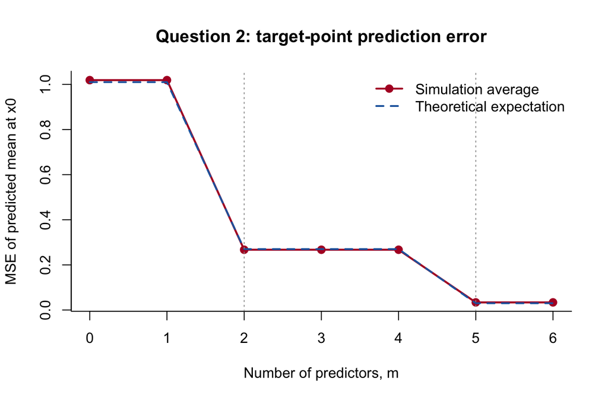

```r
plot(
  0:p2, sim_avg2, type = "o", pch = 19, lwd = 2.2, col = "#B2182B",
  xlab = "Number of predictors, m", ylab = "MSE of predicted mean at x0",
  bty = "l", main = "Question 2: target-point prediction error"
)
lines(0:p2, theory_tbl[, "expected_error"], lty = 2, lwd = 2, col = "#2166AC")
abline(v = c(2, 5), lty = 3, col = "gray60")
legend("topright", bty = "n", legend = c("Simulation average", "Theoretical expectation"),
       col = c("#B2182B", "#2166AC"), lty = c(1, 2), pch = c(19, NA), lwd = 2)
```

The smallest predictor count achieving the minimum expected error is $m=5$.

3. Although all six coefficients are nonzero, $\mathbf{x}*0=(0,1,0,0,1,0)^{\mathsf T}$ has nonzero entries only for predictors 2 and 5, so only $\beta_2$ and $\beta_5$ contribute to $\mu_0$. Unlike the test MSE in Question 1, which averages error over all rows of $\mathbf X*{\mathrm{all}}$, this error is specific to the single target $\mathbf{x}_0$.

## Question 3: The optimism correction

Choose one candidate model before observing the response. Let $p$ be its number of predictors and let $\mathbf X\in\mathbb R^{n\times(p+1)}$ be its full-rank design matrix, including the intercept. The model has $p+1$ fitted coefficients. Let

$$\mathbf H
=\mathbf X
(\mathbf X^{\mathsf T}\mathbf X)^{-1}
\mathbf X^{\mathsf T}$$

be its hat matrix. Suppose

$$\mathbf y=\boldsymbol\mu+\boldsymbol\epsilon,
\qquad
\mathbf y^*=\boldsymbol\mu+\boldsymbol\epsilon^*,$$

Conditional on the fixed design $\mathbf X$, the two error vectors are independent, have mean zero, and have covariance matrix $\sigma^2\mathbf I_n$. Define

$$\operatorname{MSE}_{\mathrm{train}}
=
\frac{1}{n}
\left\lVert
\mathbf y-\mathbf H\mathbf y
\right\rVert_2^2,
\qquad
\operatorname{MSE}_{\mathrm{test}}
=
\frac{1}{n}
\left\lVert
\mathbf y^*-\mathbf H\mathbf y
\right\rVert_2^2.$$

The conditional bias vector of the fitted mean is

$$E(\mathbf H\mathbf y\mid\mathbf X)-\boldsymbol\mu
=
-(\mathbf I_n-\mathbf H)\boldsymbol\mu.$$

Let $B^2$ denote the **total squared approximation bias**:

$$B^2
=\left\lVert
(\mathbf I_n-\mathbf H)\boldsymbol\mu
\right\rVert_2^2.$$

Thus, $B^2/n$ is the mean squared approximation bias.

You may use

$$\mathbf H^{\mathsf T}=\mathbf H,
\qquad
\mathbf H^2=\mathbf H,
\qquad
\operatorname{tr}(\mathbf H)=p+1.$$

For any fixed matrix $\mathbf A$, you may also use

$$E\!\left(
\boldsymbol\epsilon^{\mathsf T}
\mathbf A
\boldsymbol\epsilon
\mid \mathbf X
\right)
=\sigma^2\operatorname{tr}(\mathbf A).$$

1. Derive

$$E(\operatorname{MSE}_{\mathrm{train}}\mid\mathbf X)
=\frac{B^2}{n}
+\sigma^2\left(1-\frac{p+1}{n}\right),$$

and

$$E(\operatorname{MSE}_{\mathrm{test}}\mid\mathbf X)
=\frac{B^2}{n}
+\sigma^2\left(1+\frac{p+1}{n}\right).$$

2. Deduce the expected optimism, defined as $E(\operatorname{MSE}_{\mathrm{test}}-\operatorname{MSE}_{\mathrm{train}}\mid\mathbf X)$. For

$$n=120,
\qquad
p=4,
\qquad
\frac{B^2}{n}=0.04,
\qquad
\sigma^2=1,$$

calculate the expected training MSE, expected test MSE, and their difference. Explain why the ordering need not hold for every realized pair of responses.

3. Continue with $n=120$ and $p=4$. Suppose the candidate model has residual sum of squares $\operatorname{RSS}=116.4$, and suppose a common estimate of the error variance is $\widehat\sigma^2=0.96$.

Calculate

$$\widehat{\operatorname{MSE}}_{\mathrm{test}}
=\frac{
\operatorname{RSS}+2(p+1)\widehat\sigma^2
}{n},$$

and

$$C_p
=\frac{\operatorname{RSS}}{\widehat\sigma^2}
-n+2(p+1).$$

Show how these two quantities are related, and explain why minimizing $C_p$ is equivalent to minimizing the corrected test MSE when $n$ and $\widehat\sigma^2$ are common to all candidate models.

## Solution

1. derivation

Write $\mathbf y - \mathbf H\mathbf y = (\mathbf I_n-\mathbf H)\boldsymbol\mu + (\mathbf I_n-\mathbf H)\boldsymbol\epsilon$. The two terms are orthogonal in expectation because $E[(\mathbf I_n-\mathbf H)\boldsymbol\mu]^{\mathsf T}(\mathbf I_n-\mathbf H)\boldsymbol\epsilon=0$ conditional on $\mathbf X$ (the first factor is fixed, the second has mean zero). Since $\mathbf I_n-\mathbf H$ is symmetric idempotent,

$$E\big(\lVert\mathbf y-\mathbf H\mathbf y\rVert_2^2\mid\mathbf X\big)
=B^2+\sigma^2\operatorname{tr}(\mathbf I_n-\mathbf H)
=B^2+\sigma^2\big(n-(p+1)\big),$$

using $\operatorname{tr}(\mathbf I_n-\mathbf H)=n-\operatorname{tr}(\mathbf H)=n-(p+1)$. Dividing by $n$ gives the stated training-MSE expectation.

For the test residual, $\mathbf y^*-\mathbf H\mathbf y=(\mathbf I_n-\mathbf H)\boldsymbol\mu+\boldsymbol\epsilon^*-\mathbf H\boldsymbol\epsilon$. All cross-expectations vanish (fixed bias term against mean-zero noise, and $\boldsymbol\epsilon^*\perp\boldsymbol\epsilon$), so

$$E\big(\lVert\boldsymbol\epsilon^*-\mathbf H\boldsymbol\epsilon\rVert_2^2\mid\mathbf X\big)
= n\sigma^2+\sigma^2\operatorname{tr}(\mathbf H)
= \sigma^2\big(n+(p+1)\big),$$

giving $E(\operatorname{MSE}_{\mathrm{test}}\mid\mathbf X)=B^2/n+\sigma^2(1+(p+1)/n)$ after dividing by $n$.

**Show the starter code**

```r
n3 <- 120
p3 <- 4
RSS3 <- 116.4
sigma2_hat3 <- 0.96

MSE_test_hat <- (RSS3 + 2 * (p3 + 1) * sigma2_hat3) / n3
Cp3 <- RSS3 / sigma2_hat3 - n3 + 2 * (p3 + 1)

cat(sprintf("MSE_test_hat = %.4f\n", MSE_test_hat))
```

```
MSE_test_hat = 1.0500
```

**Show the starter code**

```r
cat(sprintf("Cp           = %.4f\n", Cp3))
```

```
Cp           = 11.2500
```

**Show the starter code**

```r
cat(sprintf("Check: sigma2_hat*(Cp+n)/n = %.4f\n", sigma2_hat3 * (Cp3 + n3) / n3))
```

```
Check: sigma2_hat*(Cp+n)/n = 1.0500
```

With $n=120$, $p=4$, $\mathrm{RSS}=116.4$, and $\hat\sigma^2=0.96$,

$$\widehat{\mathrm{MSE}}_{\mathrm{test}}
=\frac{116.4+2(5)(0.96)}{120}=1.05,$$

$$C_p=\frac{116.4}{0.96}-120+2(5)=11.25.$$

They are related by

$$\widehat{\mathrm{MSE}}_{\mathrm{test}}
=\frac{\hat\sigma^2}{n}(C_p+n).$$

So when $n$ and $\hat\sigma^2$ are common across models, minimizing $C_p$ is equivalent to minimizing the corrected test MSE.

## Question 4: Comparing Mallows’ $C_p$, AIC, and BIC

Use `data/diabetes.csv`, with `y` as the response. Use rows 1 through 370 as the training data, and let $n=370$ denote the training sample size. Do not use rows 371 through 442 in this question. Fit the following ordinary least-squares models, each with an intercept.

| Model | Predictors | $p$ |
| --- | --- | --- |
| Model A | `bmi`, `bp`, `s5`, `sex`, `s1`, `s2`, `s4` | 7 |
| Model B | all predictors in Model A, followed by `s6` | 8 |
| Full reference | all ten predictors | 10 |

Here $p$ counts predictors, so each model has $p+1$ fitted coefficients including the intercept. Estimate one common noise variance from the full reference model, using $p=10$:

$$\widehat\sigma^2
=\frac{\operatorname{RSS}_{\mathrm{full}}}{n-(p+1)}.$$

For Models A and B, calculate

$$C_p
=\frac{\operatorname{RSS}}{\widehat\sigma^2}
-n+2(p+1),$$

$$\operatorname{AIC}^{\mathrm{red}}
=n\log\left(\frac{\operatorname{RSS}}{n}\right)+2(p+1),$$

and

$$\operatorname{BIC}^{\mathrm{red}}
=n\log\left(\frac{\operatorname{RSS}}{n}\right)
+(p+1)\log(n).$$

The reduced AIC and BIC omit constants shared by the two candidate models. Smaller values are preferred within each criterion.

1. Fit the three models. Report $p$, RSS, the residual degrees of freedom of the full model, and $\widehat\sigma^2$.
2. Calculate $C_p$, reduced AIC, and reduced BIC for Models A and B. State which model each criterion selects. Do not compare numerical values across different criteria.
3. Compare the improvement in fit from adding `s6` with the one-parameter penalty under each criterion. Use this comparison to explain any disagreement. Why does selecting a model not establish that it is the true data-generating model?

## Solution

**Show the starter code**

```r
find_data_file <- function() {
  candidates <- c(
    file.path(getwd(), "data", "diabetes.csv"),
    file.path("data", "diabetes.csv"),
    file.path("..", "..", "data", "diabetes.csv"),
    file.path("..", "..", "..", "data", "diabetes.csv"),
    "/Users/rainashrivastava/Desktop/stat432-fall2026/data/diabetes.csv"
  )
  found <- candidates[file.exists(candidates)]
  if (length(found) == 0) stop("diabetes.csv not found in expected locations")
  found[1]
}

diabetes <- read.csv(find_data_file())
train4 <- diabetes[1:370, ]
n4 <- nrow(train4)

model_spec <- list(
  A = c("bmi", "bp", "s5", "sex", "s1", "s2", "s4"),
  B = c("bmi", "bp", "s5", "sex", "s1", "s2", "s4", "s6"),
  Full = c("age", "sex", "bmi", "bp", "s1", "s2", "s3", "s4", "s5", "s6")
)

rss_of <- function(vars) sum(residuals(lm(y ~ ., data = train4[, c(vars, "y")]))^2)

rss4 <- vapply(model_spec, rss_of, numeric(1))
p4 <- vapply(model_spec, length, numeric(1))

resid_df_full <- n4 - (p4["Full"] + 1)
sigma2_hat4 <- unname(rss4["Full"] / resid_df_full)

cat("n =", n4, "\n")
```

```
n = 370
```

**Show the starter code**

```r
cat("Residual df, full model:", resid_df_full, "\n")
```

```
Residual df, full model: 359
```

**Show the starter code**

```r
cat("sigma2_hat:", sigma2_hat4, "\n\n")
```

```
sigma2_hat: 3034.684
```

**Show the starter code**

```r
print(data.frame(model = names(rss4), p = p4, RSS = rss4), row.names = FALSE)
```

```
 model  p     RSS
     A  7 1098909
     B  8 1089717
  Full 10 1089452
```

1. $p=7$ for Model A, $p=8$ for Model B, and $p=10$ for the full reference model, which has $370-11=359$ residual degrees of freedom and $\widehat\sigma^2\approx 3034.68$.

**Show the starter code**

```r
Cp_stat <- function(rss, p) rss / sigma2_hat4 - n4 + 2 * (p + 1)
AIC_red <- function(rss, p) n4 * log(rss / n4) + 2 * (p + 1)
BIC_red <- function(rss, p) n4 * log(rss / n4) + (p + 1) * log(n4)

criteria_tbl <- data.frame(
  model = c("A", "B"),
  p = c(p4["A"], p4["B"]),
  RSS = c(rss4["A"], rss4["B"])
)
criteria_tbl$Cp <- Cp_stat(criteria_tbl$RSS, criteria_tbl$p)
criteria_tbl$AIC_red <- AIC_red(criteria_tbl$RSS, criteria_tbl$p)
criteria_tbl$BIC_red <- BIC_red(criteria_tbl$RSS, criteria_tbl$p)
print(criteria_tbl, row.names = FALSE, digits = 7)
```

```
 model p     RSS       Cp  AIC_red  BIC_red
     A 7 1098909 8.116253 2974.640 3005.948
     B 8 1089717 7.087434 2973.532 3008.754
```

**Show the starter code**

```r
cat("\nCp selects:  ", c("A", "B")[which.min(criteria_tbl$Cp)], "\n")
```

```
Cp selects:   B
```

**Show the starter code**

```r
cat("AIC selects: ", c("A", "B")[which.min(criteria_tbl$AIC_red)], "\n")
```

```
AIC selects:  B
```

**Show the starter code**

```r
cat("BIC selects: ", c("A", "B")[which.min(criteria_tbl$BIC_red)], "\n")
```

```
BIC selects:  A
```

$C_p$ and reduced AIC both prefer Model B; reduced BIC prefers Model A.

**Show the starter code**

```r
fit_gain_loglik <- n4 * log(rss4["A"] / rss4["B"])
fit_gain_cp <- (rss4["A"] - rss4["B"]) / sigma2_hat4

cat(sprintf("AIC/BIC-scale improvement from adding s6: %.4f\n", fit_gain_loglik))
```

```
AIC/BIC-scale improvement from adding s6: 3.1078
```

**Show the starter code**

```r
cat(sprintf("Cp-scale improvement from adding s6:      %.4f\n", fit_gain_cp))
```

```
Cp-scale improvement from adding s6:      3.0288
```

**Show the starter code**

```r
cat(sprintf("AIC penalty for one extra parameter: 2\n"))
```

```
AIC penalty for one extra parameter: 2
```

**Show the starter code**

```r
cat(sprintf("BIC penalty for one extra parameter: log(n) = %.4f\n", log(n4)))
```

```
BIC penalty for one extra parameter: log(n) = 5.9135
```

## Question 5: Validation and final test data

Use rows 1 through 370 of `diabetes.csv` as the training data and rows 371 through 442 as the final test data. Consider eleven nested candidate models. For $m=0,1,\ldots,10$, the model with $m$ predictors contains an intercept and the first $m$ predictors in this order:

`age`, `sex`, `bmi`, `bp`, `s1`, `s2`, `s3`, `s4`, `s5`, `s6`.

An analyst proposes the following procedure:

1. Fit all eleven candidate models using the training data.
2. Calculate the MSE of each model on the final test data.
3. Select the model with the smallest test MSE.
4. Report that minimum as the final estimate of prediction error.

The analyst argues that the procedure is valid because the final test data were not used to estimate the regression coefficients.

1. Identify the first step that misuses the final test data. Explain why the minimum of eleven test MSE values is generally too favorable as an estimate of the selected procedure’s future prediction error.
2. Rewrite the analysis using five-fold cross-validation within the training data. State how the predictor count is selected, what is refitted, and when the final test data may be used.
3. Suppose the analyst has already examined all eleven test MSE values. What can still be reported transparently, and what additional data would be needed for a new final evaluation?

## Solution

1. The first misuse occurs in **Step 2**, when the final test responses are used to compare the eleven models. Since model selection is data-dependent, the final test set is no longer an untouched holdout. Taking the minimum of eleven noisy test MSEs is also overly favorable because it tends to select the model that happened to get lucky test-set noise, biasing the reported error downward.

**Show the starter code**

```r
diabetes5 <- diabetes
train5 <- diabetes5[1:370, ]
final_test5 <- diabetes5[371:442, ]
predictors5 <- c("age", "sex", "bmi", "bp", "s1", "s2", "s3", "s4", "s5", "s6")
n5 <- nrow(train5)

fit_and_mse <- function(vars, dtrain, deval) {
  fit <- if (length(vars) == 0) lm(y ~ 1, data = dtrain) else
    lm(y ~ ., data = dtrain[, c(vars, "y")])
  mean((deval$y - predict(fit, newdata = deval))^2)
}

naive_mse <- sapply(0:10, function(m) fit_and_mse(predictors5[seq_len(m)], train5, final_test5))
names(naive_mse) <- 0:10
print(round(naive_mse, 2))
```

```
      0       1       2       3       4       5       6       7       8       9
5822.89 5527.79 5527.21 3719.24 3246.82 3234.92 3207.61 2636.50 2624.92 2369.34
     10
2484.78
```

**Show the starter code**

```r
cat("\nNaive selected m:", which.min(naive_mse) - 1,
    " reported (optimistic) error:", round(min(naive_mse), 2), "\n")
```

```
Naive selected m: 9  reported (optimistic) error: 2369.34
```

**Show the starter code**

```r
set.seed(52024)
K <- 5
fold_id <- sample(rep(1:K, length.out = n5))

cv_mse <- matrix(NA_real_, K, 11)
for (k in seq_len(K)) {
  fold_train <- train5[fold_id != k, ]
  fold_valid <- train5[fold_id == k, ]
  for (m in 0:10) {
    cv_mse[k, m + 1] <- fit_and_mse(predictors5[seq_len(m)], fold_train, fold_valid)
  }
}
cv_avg <- colMeans(cv_mse)
names(cv_avg) <- 0:10
print(round(cv_avg, 2))
```

```
      0       1       2       3       4       5       6       7       8       9
5974.93 5790.24 5826.65 3941.40 3685.98 3686.28 3694.50 3180.63 3190.28 3122.86
     10
3110.82
```

**Show the starter code**

```r
m_star <- which.min(cv_avg) - 1
cat("\nCV-selected predictor count: m =", m_star, "\n")
```

```
CV-selected predictor count: m = 10
```

**Show the starter code**

```r
final_fit_vars <- predictors5[seq_len(m_star)]
final_mse <- fit_and_mse(final_fit_vars, train5, final_test5)
cat("Final (honest) test MSE at m =", m_star, ":", round(final_mse, 2), "\n")
```

```
Final (honest) test MSE at m = 10 : 2484.78
```

Use five-fold cross-validation on rows 1–370 to compute the average validation MSE for each predictor count and select the (m) with the smallest average. Then refit the selected model on all 370 training observations. The final test set (rows 371–442) should be used **only once**, after model selection, to estimate final prediction error.

3. If all eleven test MSEs have already been examined, they can only be reported as an **exploratory comparison**, along with the cross-validation results. A new, previously unseen set of observations would be needed for a valid final evaluation.